# nbaR: R access to the Netherlands Biodiversity API

Hannes Hettling

2018-05-18

# Background

## The Netherlands Biodiversity API

The Netherlands Biodiversity API (NBA) facilitates access to the Natural History Collection at the Naturalis Biodiversity Center. Next to than museum specimen records and metadata, access to taxonomic classification and nomenclature, geographical information, and to multimedia files is provided. By using the powerful Elasticsearch engine, the NBA facilitates searching for collection- and biodiversity data in near real-time. Furthermore, by incorporating information from taxonomic databases, taxonomic name resolution can be accomplished with the NBA. Persistent Uniform Resource Identifiers (PURLs) ensure that each species accessible via the NBA is represented by a citable unambiguous web reference. Access to our data is provided via a REST interface and several clients such as the [BioPortal](http://bioportal.naturalis.nl/), a web application for browsing biodiversity data that is served by the NBA. For more information about the NBA, please see our [detailed documentation](http://docs.biodiversitydata.nl/).

## R access

The R programming language is established as a common tool in scientific resarch. To ease the access to the NBA for researchers, we developed this R client.

# Getting started

## Main data types and classes

The data served by the NBA consists of four main data types:

- Specimen
- Taxon
- Multimedia
- Geo

Additionally, the data type *Metadata* stores miscellaneous information about NBA settings. Each of the data types is modelled as an `R6` class and therefore has its own members such as fields and methods. Documentation about a specific class can be retrieved in the standard manner, e.g. `?Specimen` Each class of the data model can be instanciated and has a `toJSONString` and `toList` method returning the object’s JSON representation and the object’s data as a list datatype, respectively.

```r
# load nbaR
library('nbaR')

# instanciate specimen object
spec <- Specimen$new()

# represent data as JSON or list
spec$toJSONString()
```

```
## []
```

```r
spec$toList()
```

```
## list()
```

## API Client classes

The interaction with the API is accomplished by the API client classes:

- SpecimenClient
- TaxonClient
- MultimediaClient
- GeoClient
- MetadataClient

```r
# initialize client
client <- SpecimenClient$new()
```

The client class is by default initialized to connect to the base URL http://api.biodiversitydata.nl/v2. For testing purposes, this can be set to a different URL, see `?SpecimenClient` for details.

## Queries

### Concept

With the SpecimentClient created above, the `query` endpoint for specimens can now be reached via the `query` function.

```r
# retrieve results of empty query.
res <- client$query()
```

The `query` function then returns an object of class `Response`, which, in turn, has a field `content` of class `QueryResult`. From the `QueryResult`, the single result items can be accessed as follows:

```r
# get first element of results
spec <- res$content$resultSet[[1]]$item

# object should be of type Specimen
class(spec)
```

```
## [1] "Specimen" "R6"
```

### Passing query parameters as list

Query parameters can be specified as a list with named parameters. To query for instance for specimen records that have the type status holotype and a female sex, one can pass a named list as the `queryParams` parameter to the `query` function:

```r
# specify two query conditions
l <- list(identifications.typeStatus="holotype", sex="female")

# run query
res <- client$query(queryParams=l)
```

Note that by default, both conditions are connected by a logical `AND`. The `queryParams` passed as a list thus correspond to basic [*human readable* queries](http://docs.biodiversitydata.nl/en/latest/quickstart/#human-readable). For more advanced queries, containing different logical operators or nested subqueries, the user can specify tha query in a `QuerySpec` object.

# Advanced queries

## Using the QuerySpec object

```r
# specify search in QueryCondition object
qc <- QueryCondition$new(field="unitID", operator="EQUALS", value="L.4304195")

# build QuerySpec using above conditions
qs <- QuerySpec$new(conditions=list(qc))

# do the query
res <- client$query(querySpec=qs)
```

```r
# specify multiple conditions
q1 <- QueryCondition$new(field = "sex", operator="EQUALS",
                         value="female")
q2 <- QueryCondition$new(field="identifications.defaultClassification.family",
                         operator="EQUALS",
                         value="Equidae")
q3 <- QueryCondition$new(field="identifications.taxonRank",
                         operator="EQUALS", value="species")

# logical conjunction using 'or' method
q3$or<- list(QueryCondition$new(field = "identifications.taxonRank",
                                operator="EQUALS",
                                value="subspecies"))

# build QuerySpec from QueryConditions
qs <-QuerySpec$new(conditions=list(q1, q2, q3))

# call API
res <-client$query(querySpec=qs)
```

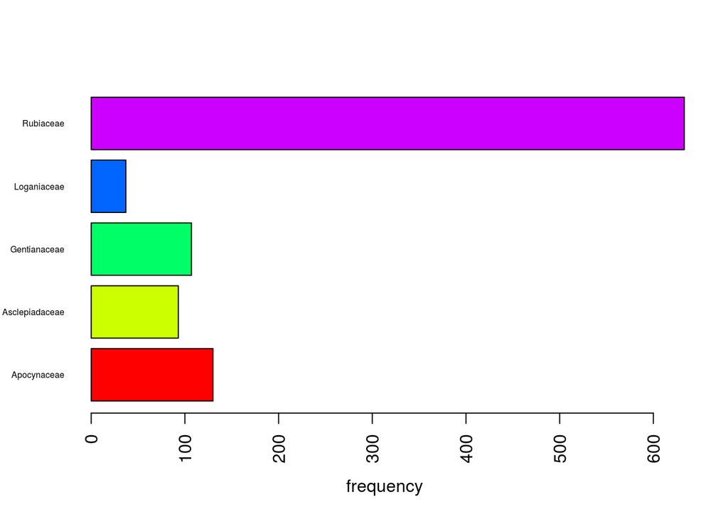

```r
# get 1000 specimen items from plant order 'Gentianales'
qc <- QueryCondition$new(field = "identifications.defaultClassification.order",
                         operator="EQUALS",
                         value="Gentianales")
qs <- QuerySpec$new(conditions=list(qc), size=1000)
res <- client$query(querySpec=qs)

# extract orders from first identification of each specimen
families <- unlist(sapply(res$content$resultSet,
                          function(x)x$item$identifications[[1]]$defaultClassification$family))
# plot frequencies
barplot(table(families), horiz=T,
        col=rainbow(length(unique(families))),
        las=2, xlab="frequency", cex.names=0.5)
```

# Datatype specific services

## Specimen occurrence services

Specimen records constitute the core of data served by the NBA. Museum specimens can represent a whole variety of different objects such as plants, animals or single parts thereof, DNA samples, fossils, rocks or meteorites. For detailed information of the data model, please refer to the [official documentation in the NBA](http://docs.biodiversitydata.nl/en/latest/doc-spec-services/specimen/).